# Планирование локальной сети организации

Лабораторная работа №3

Гафоров Нурмухаммад

Российский университет дружбы народов, Москва, Россия

22.02.2026

# Цель работы

## Цель

Изучение принципов планирования локальной сети организации  
и разработка схем L1, L2, L3 с формированием плана адресного пространства.

# Выполнение

## Основные параметры сети

- Базовое адресное пространство: **10.128.0.0/16**
- Использование VLAN для сегментации
- Централизованная маршрутизация через основной шлюз
- Разделение пользователей по функциональному признаку

## Физический уровень

- Центральный шлюз: `msk-donskaya-ngaforov-gw-1`
- Коммутаторы доступа и распределения
- Серверная ферма
- Пользовательские сегменты

## Схема L1

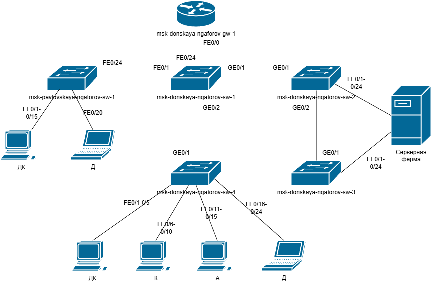

Схема L1 — физическая топология

## Логическая сегментация (VLAN)

Используемые VLAN:

- VLAN 2 — management
- VLAN 3 — servers
- VLAN 101 — dk
- VLAN 102 — departments
- VLAN 103 — adm
- VLAN 104 — other

## Схема L2

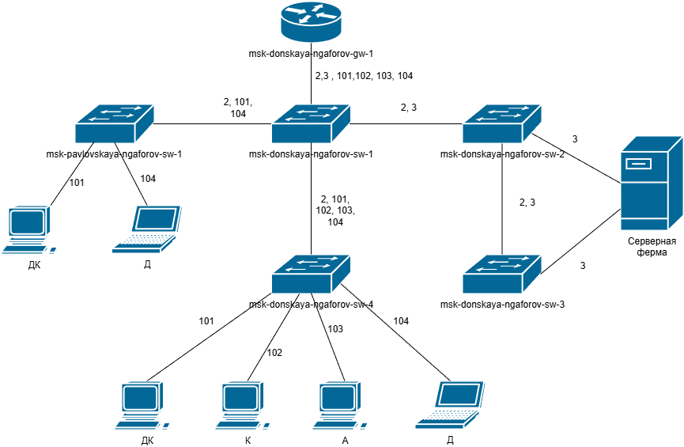

Схема L2 — распределение VLAN

## IP-адресация 10.128.0.0/16

Подсети /24:

- 10.128.0.0 — серверная ферма
- 10.128.1.0 — управление
- 10.128.2.0 — point-to-point
- 10.128.3.0 — ДК
- 10.128.4.0 — кафедры
- 10.128.5.0 — администрация
- 10.128.6.0 — другие пользователи

## Схема L3

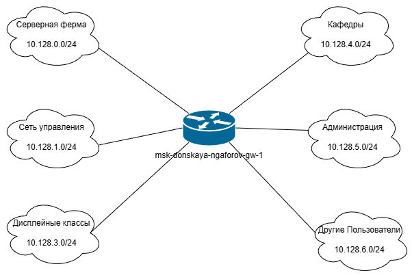

Схема L3 — логическая адресация

## Таблица VLAN

| VLAN | Назначение |
| --- | --- |
| 2 | Управление |
| 3 | Серверная ферма |
| 101 | Дисплейные классы |
| 102 | Кафедры |
| 103 | Администрация |
| 104 | Другие пользователи |

## Распределение подсетей /24

| Подсеть | Назначение |
| --- | --- |
| 10.128.0.0/24 | Серверы |
| 10.128.1.0/24 | Управление |
| 10.128.2.0/24 | Point-to-Point |
| 10.128.3.0/24 | ДК |
| 10.128.4.0/24 | Кафедры |
| 10.128.5.0/24 | Администрация |
| 10.128.6.0/24 | Другие пользователи |

## 172.16.0.0/12

- 172.16.0.0/24 — серверы
- 172.16.1.0/24 — управление
- 172.16.2.0/24 — P2P
- 172.16.3.0/24 — ДК
- 172.16.4.0/24 — кафедры
- 172.16.5.0/24 — администрация
- 172.16.6.0/24 — другие пользователи

## 172.16.0.0/12

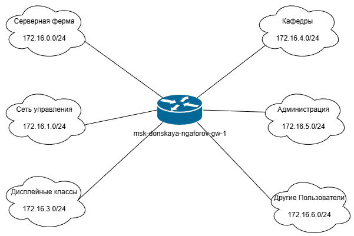

L3 для 172.16.0.0/12

## 192.168.0.0/16

- 192.168.0.0/24 — серверы
- 192.168.1.0/24 — управление
- 192.168.2.0/24 — P2P
- 192.168.3.0/24 — ДК
- 192.168.4.0/24 — кафедры
- 192.168.5.0/24 — администрация
- 192.168.6.0/24 — другие пользователи

## 192.168.0.0/16

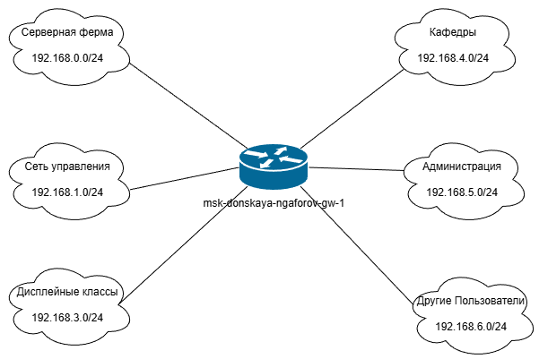

L3 для 192.168.0.0/16

# Вывод

## Вывод

В ходе работы:

- Разработаны схемы L1, L2, L3
- Выполнено разбиение сети 10.128.0.0/16 на подсети /24
- Реализована сегментация с использованием VLAN
- Подготовлен альтернативный план адресации для:
  - 172.16.0.0/12
  - 192.168.0.0/16
- Подтверждена универсальность архитектуры сети